# course project

# The goal

here we’ll be predicting the “classe” variable for testing set based on correlaton between the “classe” variable in the training set and other variables in the training set.

“classe” is the manner in which few persons did some exercises.

# Preparations

## Getting Data

```r
getDataset <- function(url, filename) {
    if (!file.exists(filename)) {
        download.file(url,destfile=filename,method="curl")
    }
    read.csv(filename, na.strings=c("NA","#DIV/0!",""))
}

trainUrl <- "http://d396qusza40orc.cloudfront.net/predmachlearn/pml-training.csv"
testUrl <- "http://d396qusza40orc.cloudfront.net/predmachlearn/pml-testing.csv"

training <- getDataset(trainUrl,"pml-training.csv")
testing <- getDataset(trainUrl,"pml-testing.csv")
```

## Train and test to select better method

```r
inTrain <- createDataPartition(y=training$classe, p=0.6, list=FALSE)
trainTraining <- training[inTrain, ]
testTraining <- training[-inTrain, ]
dim(trainTraining)
```

```
[1] 11776   160
```

```r
dim(testTraining)
```

```
[1] 7846  160
```

## Filter empty columns

“classe” is an unordered factor variable. So in general our problem is classification. And we need to detect features (variables) that are important for solving our problem.

```r
library(caret)

nzVarsFileName <- 'nearZeroVars.Rdata'

if (file.exists(nzVarsFileName)) {
    load(file=nzVarsFileName) # nzVars will be available
} else {
    nzVars <- nearZeroVar(trainTraining, saveMetrics=TRUE)
    # use it later
    save(nzVars, file=nzVarsFileName)
}
trainingCleaned <- trainTraining[,!nzVars$nzv]
dim(trainingCleaned)
```

```
[1] 11776   130
```

## Filter almost empty columns

```r
countNaRatio <- colSums(is.na(trainingCleaned)) / nrow(trainingCleaned)
almostNaCols <- which(countNaRatio > 0.66)
trainingCleaned <- trainingCleaned[,-almostNaCols]
dim(trainingCleaned)
```

```
[1] 11776    59
```

```r
irrelevantCols <- grep("X|user_name|timestamp|_window",names(trainingCleaned))
trainingCleaned <- trainingCleaned[,-irrelevantCols]
dim(trainingCleaned)
```

```
[1] 11776    53
```

# Train few models

Trees, random forest, boosting are among the methods that are ok with detecting features for a classification problem.

## Random forest

```r
library(caret)
library(randomForest)
set.seed(8001)

modelFitRFFileName <- 'modelFitRF.Rdata'
if (file.exists(modelFitRFFileName)) {
    load(file=modelFitRFFileName) # modelFitRF will be available
} else {
    modelFitRF <- randomForest(classe~., data=trainingCleaned, type="class")
    # use it later
    save(modelFitRF, file=modelFitRFFileName)
}
```

## Decision Tree

Presumably here the out of sample error (1 - accuracy) will be not so small.

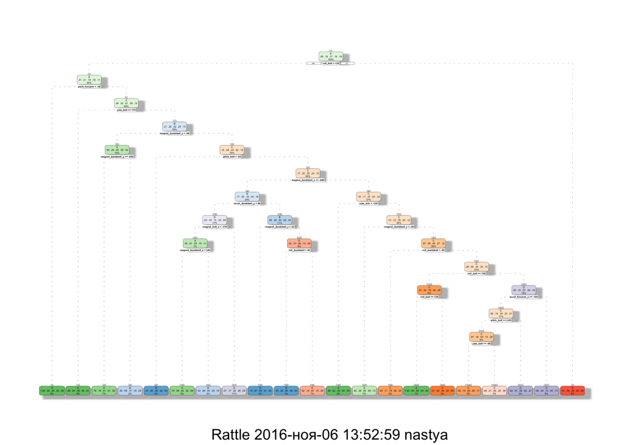

```r
library(rpart)
set.seed(8001)
modelFitDT <- rpart(classe ~ ., data=trainingCleaned, method="class")

library(rattle)
fancyRpartPlot(modelFitDT)
```

## Add cross-validation

See if we can improve accuracy

```r
trCtrl <- trainControl(method="cv", number=7, verboseIter=FALSE,
                       preProcOptions="pca", allowParallel=TRUE)
```

### Random forest + control

```r
modelFitRFWithControlFileName <- 'modelFitRFWithControl.Rdata'
if (file.exists(modelFitRFWithControlFileName)) {
    load(file=modelFitRFWithControlFileName)
    # modelFitRFWithControl will be available
} else {
    modelFitRFWithControl <- train(classe~.,
                                   data=trainingCleaned,
                                   method="rf", trControl=trCtrl)
    # use it later
    save(modelFitRFWithControl, file=modelFitRFWithControlFileName)
}
```

### Decision tree + control

```r
modelFitDTWithControlFileName <- 'modelFitDTWithControl.Rdata'
if (file.exists(modelFitDTWithControlFileName)) {
    load(file=modelFitDTWithControlFileName)
    # modelFitRFWithControl will be available
} else {
    modelFitDTWithControl <- train(classe~.,
                                   data=trainingCleaned,
                                   method="rpart", trControl=trCtrl)
    # use it later
    save(modelFitDTWithControl, file=modelFitDTWithControlFileName)
}
```

### Boosting + control

```r
modelFitGMBWithControlFileName='modelFitGMBWithControl.Rdata'
if (file.exists(modelFitGMBWithControlFileName)) {
    load(file=modelFitGMBWithControlFileName)
    # modelFitRFWithControl will be available
} else {
    modelFitGMBWithControl <- train(classe~.,
                                   data=trainingCleaned,
                                   method="gbm", trControl=trCtrl)
    # use it later
    save(modelFitGMBWithControl, file=modelFitGMBWithControlFileName)
}
```

## Which model is better?

```r
getMatrix <- function(modelFit, dataset, predType='class') {
    yCol <- grep("classe",names(dataset))

    prediction <- predict(modelFit,
                          newdata=dataset[,-yCol], type=predType)
    # show only accuracy
    confusionMatrix(prediction, dataset$classe)$overall["Accuracy"]
}

# reduce columns to those that were used in training
testTrainingCleaned <- testTraining[,names(trainingCleaned)]

getMatrix(modelFitDT, testTrainingCleaned)
```

```
 Accuracy
0.7127199
```

```r
getMatrix(modelFitRF, testTrainingCleaned)
```

```
Accuracy
0.997196
```

```r
getMatrix(modelFitDTWithControl, testTrainingCleaned, 'raw')
```

```
 Accuracy
0.4954117
```

```r
getMatrix(modelFitRFWithControl, testTrainingCleaned, 'raw')
```

```
 Accuracy
0.9966862
```

```r
getMatrix(modelFitGMBWithControl, testTrainingCleaned, 'raw')
```

```
 Accuracy
0.9664797
```

Cross-validation is not helping. There is no big difference between train with controls or without controls when using random forest formula. But training with controls is much slower.

And the winner is (wait for it…) Random Forest method!

## Answers

```r
p1 <- predict(modelFitRF, newdata=testing, type='class')
p2 <- predict(modelFitGMBWithControl, newdata=testing, type='raw')
p3 <- predict(modelFitRFWithControl, newdata=testing, type='raw')
# hide output
```

# Acknowledgements

The data for this project come from this source: http://groupware.les.inf.puc-rio.br/har. They have been very generous in allowing their data to be used for this kind of assignment.

More information is available from the website (see the section on the Weight Lifting Exercise Dataset).